# 5. Paket Yöneticisi ile Python Paketleri Kurulumu

## 5.1 AppJar paketi

Pynar Editöründe görsel programlama yapabilmek için Appjar paketi bilgisayarınızda kurulu olmalıdır. Eğer bilgisayarınızda kurulu değilse uygulamayı çalıştırdığınzıda aşağıdaki gibi bir uyarı ile karşılaşırsınız.

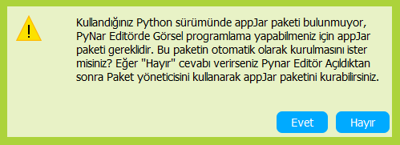

image

Hayır seçeneğini seçerseniz görselde de anlatıldığı gibi görsel programlama yapabilmek için 5.2 bölümündede anlatıldığı gibi paket yöneticisinden kurulum gerçekleştirmelisiniz.

Evet seçeneğini seçerseniz aşağıdaki gibi bir kurulum ekranıyla karşılaşırsınız ve kurulum bittiğinde editör çalışır. Sol Menüde görsel bileşenler menüsünü kullarak görsel programlama yapabilirsiniz.

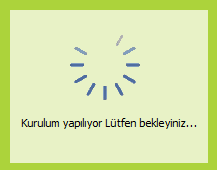

image

## 5.2 Paket Arama ve Kurma

**Örnek: AppJar paketinin kurulumu**

Ayarlar sekmesi altındaki kutu ikonuna tıklayarak Paket Yöneticisi açılır.

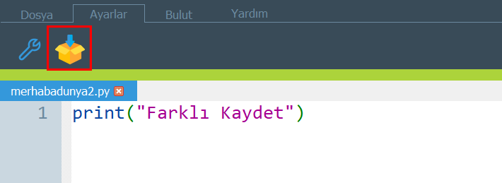

Paket yöneticisine tıklandığında karşınıza kurulu paketleri görebildiğiniz veya yeni paketler kurabildiğiniz bir pencere çıkar.

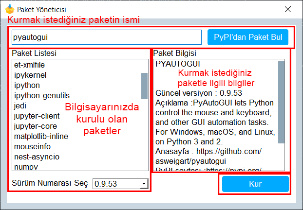

Arama kutusuna AppJar yazıp PyPl’dan Paket Bul butonuna tıklayın.

[figure not shown]

2

Paket bulunduğunda pencerenin sağ tarafında paketle ilgili bilgileri ve kur butonunu görebilirsiniz.

[figure not shown]

3

Kur butonuna tıkladığınızda kurulum başlayacaktır. Kurulum bitene kadar bir süre bekleyiniz.

[figure not shown]

4

Kurulum işlemi bittiğinde “Kurulum Başarı ile Tamamlandı.” yazan bir pencere çıkacaktır.

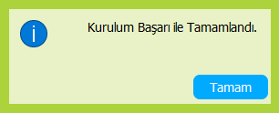

5

Paket Kullanıma hazır.

## 5.3 Paket kaldırma

**Örnek: AppJar paketinin kaldırılması**

Ayarlar sekmesi altındaki kutu ikonuna tıklayarak Paket Yöneticisi açılır.

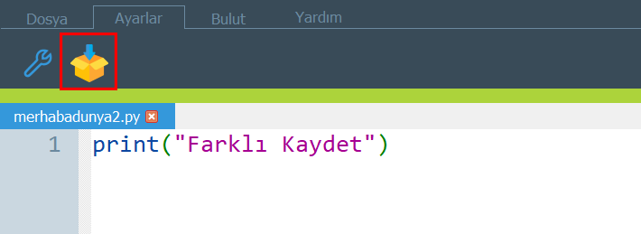

Paket Listesi altında bilgisayarınızda bulunan paketleri görebilirsiniz.

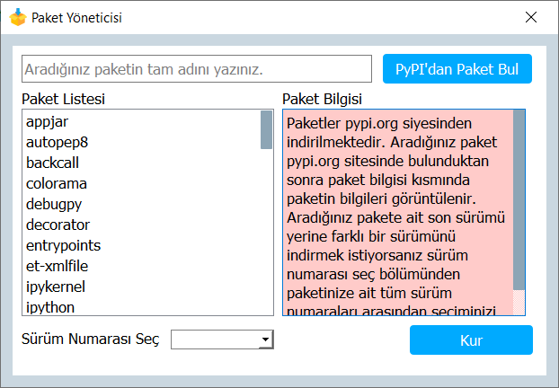

7

AppJar ismini paket listesinden buluyoruz.

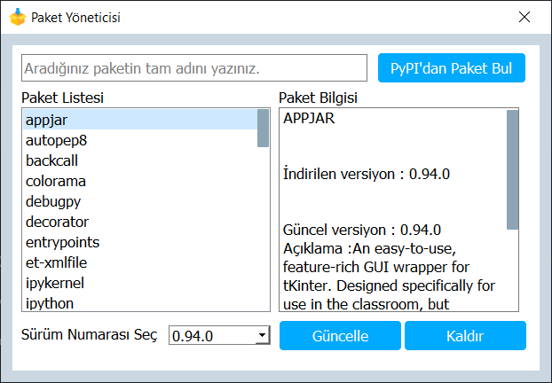

8

Kaldır butonuna tıklayarak kaldırma işlemini başlatınız.

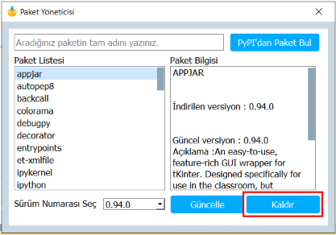

9

Kaldırma işlemi yapılırken bir süre bekleyiniz. Kaldırma işlemi bittiğinde “Paket Başarılı Bir Şekilde Kaldırıldı.” yazan bir pencere çıkacaktır.

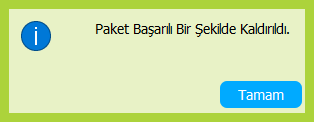

6

Paket kaldırıldı.